# IDS 572 Assigment 1 Part A

Lauren Sansone, Joshua Pollack, Lina Quiceno Bejarano

### **Question 2a - Part(I)**

**What is the proportion of defaults (‘charged off’ vs ‘fully paid’ loans) in the data?**

The total number of loans is 81,022 loans. The proportion of fully paid loans is 69,195 and charged off loans are 11,827. Charged off loans represent 14.6% of the total amount of loans. It is expected that the vast majority of loans funded would be fully paid (85.4% in this case).

|  | loan_status | nLoans | prctTot |
| --- | --- | --- | --- |
| 1 | Charged Off | 11827 | 14.59727 |
| 2 | Fully Paid | 69195 | 85.40273 |

**How does default rate vary with loan grade?**

Exploring a table of percent of charged off loans and fully paid loans by total loans in each grade, the grade with the highest percentage of charged off loans is grade G, with 41.8% of loans charged off. This is expected as loan grade G is the riskiest grade category. Default rate increases as loan grade decreases nearly linearly. This is expected as the loans that are considered riskier by loan grade have a greater percentage of charged off grades.

| grade | loan_status | nLoans | prctTot |
| --- | --- | --- | --- |
| A | Charged Off | 1108 | 5.43084 |
| A | Fully Paid | 19294 | 94.56916 |
| B | Charged Off | 2682 | 11.46203 |
| B | Fully Paid | 20717 | 88.53797 |
| C | Charged Off | 4116 | 18.23094 |
| C | Fully Paid | 18461 | 81.76906 |
| D | Charged Off | 2647 | 24.50472 |
| D | Fully Paid | 8155 | 75.49528 |
| E | Charged Off | 1045 | 32.74835 |
| E | Fully Paid | 2146 | 67.25165 |

[output cut: 4 more lines]

| loan_status | grade | nLoans | prctTot |
| --- | --- | --- | --- |
| Charged Off | A | 1108 | 9.36839435 |
| Charged Off | B | 2682 | 22.67692568 |
| Charged Off | C | 4116 | 34.80172487 |
| Charged Off | D | 2647 | 22.38099264 |
| Charged Off | E | 1045 | 8.83571489 |
| Charged Off | F | 191 | 1.61494885 |
| Charged Off | G | 38 | 0.32129872 |
| Fully Paid | A | 19294 | 27.88351760 |
| Fully Paid | B | 20717 | 29.94002457 |
| Fully Paid | C | 18461 | 26.67967339 |

[output cut: 4 more lines]

**Does it vary with sub-grade? And is this what you would expect, and why?**

The proportion of loans that are charged off does vary by subgrade. The percent of loans that are charged off generally increase as loan grade decreases. Again, this is as expected as loans that are considered riskier by grade have a greater percentage of charged off loans.

| sub_grade | loan_status | nLoans | prctTot |
| --- | --- | --- | --- |
| A1 | Charged Off | 95 | 3.143614 |
| A1 | Fully Paid | 2927 | 96.856386 |
| A2 | Charged Off | 165 | 4.605080 |
| A2 | Fully Paid | 3418 | 95.394920 |
| A3 | Charged Off | 154 | 4.340474 |
| A3 | Fully Paid | 3394 | 95.659526 |
| A4 | Charged Off | 281 | 5.806985 |
| A4 | Fully Paid | 4558 | 94.193015 |
| A5 | Charged Off | 413 | 7.634011 |
| A5 | Fully Paid | 4997 | 92.365989 |

[output cut: 60 more lines]

| loan_status | sub_grade | nLoans | prctTot |
| --- | --- | --- | --- |
| Charged Off | A1 | 95 | 0.803246808 |
| Charged Off | A2 | 165 | 1.395112877 |
| Charged Off | A3 | 154 | 1.302105352 |
| Charged Off | A4 | 281 | 2.375919506 |
| Charged Off | A5 | 413 | 3.492009808 |
| Charged Off | B1 | 373 | 3.153800626 |
| Charged Off | B2 | 479 | 4.050054959 |
| Charged Off | B3 | 531 | 4.489726896 |
| Charged Off | B4 | 546 | 4.616555339 |
| Charged Off | B5 | 753 | 6.366787858 |

[output cut: 60 more lines]

### **Question 2a - Part(II)**

**How many loans are there in each grade? And do loan amounts vary by grade?**  
**Does interest rate for loans vary with grade, subgrade? Look at the average, standard-deviation, min and max of interest rate by grade and subgrade. Is this what you expect, and why?**

The number of loans per grade:  
A = 20402; B = 23399; C = 22577; D = 10802; E = 3191; F = 560; G = 91

The majority of loans are in grade A, B and C with the least amount of loans in grade G. This is expected as it would make sense for the company to invest in less risky loans.

The average loan amount does not vary much by grade. The average range of loan amounts are between $10,000 to $14,000.

Interest rates certainly vary by grade and subgrade. Average interest rates increase as loan grades decrease both across grades and within subgrades. This is expected as higher interest rates are applied to riskier loans. It shows that Lending Club is basing interest rates given off of loan grades.

Standard deviations in groups and subgroups are small. This makes sense as interest rates are likely determined by loan grade.

|  | grade | n |
| --- | --- | --- |
| 1 | A | 20402 |
| 2 | B | 23399 |
| 3 | C | 22577 |
| 4 | D | 10802 |
| 5 | E | 3191 |
| 6 | F | 560 |
| 7 | G | 91 |

|  | grade | sum(loan_amnt) |
| --- | --- | --- |
| 1 | A | 288605200 |
| 2 | B | 291509175 |
| 3 | C | 258857100 |
| 4 | D | 131244900 |
| 5 | E | 40072800 |
| 6 | F | 5694425 |
| 7 | G | 1138325 |

|  | grade | mean(loan_amnt) |
| --- | --- | --- |
| 1 | A | 14145.93 |
| 2 | B | 12458.19 |
| 3 | C | 11465.52 |
| 4 | D | 12150.06 |
| 5 | E | 12558.07 |
| 6 | F | 10168.62 |
| 7 | G | 12509.07 |

|  | grade | mean(int_rate) |
| --- | --- | --- |
| 1 | A | 7.249607 |
| 2 | B | 10.711802 |
| 3 | C | 13.672434 |
| 4 | D | 16.531698 |
| 5 | E | 19.769035 |
| 6 | F | 24.119196 |
| 7 | G | 25.839890 |

```
## # A tibble: 35 x 2
##    sub_grade `mean(int_rate)`
##  * <chr>                <dbl>
##  1 A1                    6.03
##  2 A2                    6.49
##  3 A3                    7.05
##  4 A4                    7.58
##  5 A5                    8.27
##  6 B1                    8.88
##  7 B2                    9.77
##  8 B3                   10.7
##  9 B4                   11.5
## 10 B5                   12.2
## 11 C1                   12.7
## 12 C2                   13.1
```

[output cut: 23 more lines]

|  | grade | nLoans | avgInterest | stdInterest | minInt | maxInt |
| --- | --- | --- | --- | --- | --- | --- |
| 1 | A | 20402 | 7.249607 | 0.79629732 | 6.00 | 8.39 |
| 2 | B | 23399 | 10.711802 | 1.21582167 | 6.00 | 12.49 |
| 3 | C | 22577 | 13.672434 | 0.84999588 | 6.00 | 14.99 |
| 4 | D | 10802 | 16.531698 | 0.89545653 | 6.00 | 18.24 |
| 5 | E | 3191 | 19.769035 | 1.10091584 | 6.00 | 22.15 |
| 6 | F | 560 | 24.119196 | 0.79791335 | 22.99 | 25.57 |
| 7 | G | 91 | 25.839890 | 0.05932012 | 25.80 | 26.06 |

```
## # A tibble: 35 x 6
##    sub_grade nLoans avgInterest stdInterest minInt maxInt
##  * <chr>      <int>       <dbl>       <dbl>  <dbl>  <dbl>
##  1 A1          3022        6.03    0.000546   6      6.03
##  2 A2          3583        6.49    0          6.49   6.49
##  3 A3          3548        7.05    0.0650     6.99   7.12
##  4 A4          4839        7.58    0.0996     7.49   7.69
##  5 A5          5410        8.27    0.0971     8.19   8.39
##  6 B1          4123        8.88    0.251      6      9.17
##  7 B2          4604        9.77    0.326      9.49  10.2
##  8 B3          4603       10.7     0.248     10.5   11.0
##  9 B4          4628       11.5     0.162      6     11.7
## 10 B5          5441       12.2     0.260      6     12.5
## 11 C1          5410       12.7     0.298     12.4   13.0
## 12 C2          5102       13.1     0.179     13.0   13.4
```

[output cut: 23 more lines]

### **Question 2a - Part(III)**

**What are people borrowing money for (purpose)? Examine how many loans, average amounts, etc. by purpose? And within grade? Do defaults vary by purpose?**

The purpose people are borrowing money include car loans, credit cards, debt consolidation, home improvement projects, house purchases, major purchases, medical, moving, renewable energy, small business, vacations and weddings.

The majority of loans are for the purpose of debt consolidation (60%) and credit cards (23.2%). Weddings have the least amount of loans, totaling only three loans.

The average dollar amount of loans vary by purpose (ranging from the lowest average of $5,872 for vacations to the highest average of $14,425 for small business).

Across all purpose categories, the fewest number of loans are in loan grades E, F and G. Except in the credit card category, the majority count of loans are in grades B, C and D (with a slightly less number of loans in grade A). The credit card category is the only purpose with the most amount of loans in loan grade A compared to the other grades.

The highest total number of defaults are in debt consolidation, which also is the greatest category for purpose of loan. The highest percentage of defaults by purpose are from the small business category, which has 22.3% of the loans charged off.

|  | purpose | n |
| --- | --- | --- |
| 1 | car | 719 |
| 2 | credit_card | 18780 |
| 3 | debt_consolidation | 48647 |
| 4 | home_improvement | 3942 |
| 5 | house | 254 |
| 6 | major_purchase | 1402 |
| 7 | medical | 900 |
| 8 | moving | 604 |
| 9 | other | 4523 |
| 10 | small_business | 759 |

[output cut: 1 more lines]

|  | purpose | nLoans | prctTot |
| --- | --- | --- | --- |
| 1 | car | 719 | 0.8874133 |
| 2 | credit_card | 18780 | 23.1788897 |
| 3 | debt_consolidation | 48647 | 60.0417171 |
| 4 | home_improvement | 3942 | 4.8653452 |
| 5 | house | 254 | 0.3134951 |
| 6 | major_purchase | 1402 | 1.7303942 |
| 7 | medical | 900 | 1.1108094 |
| 8 | moving | 604 | 0.7454765 |
| 9 | other | 4523 | 5.5824344 |
| 10 | small_business | 759 | 0.9367826 |

[output cut: 1 more lines]

|  | purpose | nLoans | avgInterest | avgLoanAmt | defaults | prctCharged_off |
| --- | --- | --- | --- | --- | --- | --- |
| 1 | car | 719 | 11.79448 | 7819.645 | 75 | 10.43115 |
| 2 | credit_card | 18780 | 10.32606 | 13501.040 | 2326 | 12.38552 |
| 3 | debt_consolidation | 48647 | 12.13044 | 13007.644 | 7423 | 15.25891 |
| 4 | home_improvement | 3942 | 11.84430 | 11706.925 | 503 | 12.76002 |
| 5 | house | 254 | 16.32626 | 12505.118 | 48 | 18.89764 |
| 6 | major_purchase | 1402 | 11.95529 | 10172.183 | 220 | 15.69187 |
| 7 | medical | 900 | 13.76807 | 6980.722 | 141 | 15.66667 |
| 8 | moving | 604 | 15.49184 | 6542.384 | 132 | 21.85430 |
| 9 | other | 4523 | 14.08964 | 8292.953 | 718 | 15.87442 |
| 10 | small_business | 759 | 16.36622 | 14424.835 | 169 | 22.26614 |

[output cut: 1 more lines]

```
## # A tibble: 76 x 3
## # Groups:   grade [7]
##    grade purpose                n
##    <chr> <fct>              <int>
##  1 A     car                  194
##  2 A     credit_card         7487
##  3 A     debt_consolidation 10824
##  4 A     home_improvement    1043
##  5 A     house                  8
##  6 A     major_purchase       361
##  7 A     medical               73
##  8 A     moving                 8
##  9 A     other                340
## 10 A     small_business        26
## 11 A     vacation              38
```

[output cut: 65 more lines]

```
## # A tibble: 76 x 3
## # Groups:   purpose [11]
##    purpose            grade     n
##    <fct>              <chr> <int>
##  1 car                A       194
##  2 car                B       209
##  3 car                C       195
##  4 car                D        79
##  5 car                E        30
##  6 car                F         9
##  7 car                G         3
##  8 credit_card        A      7487
##  9 credit_card        B      6105
## 10 credit_card        C      3779
## 11 credit_card        D      1135
```

[output cut: 65 more lines]

|  | purpose | nLoans | defaults | prctCharged_off |
| --- | --- | --- | --- | --- |
| 1 | car | 719 | 75 | 10.43115 |
| 2 | credit_card | 18780 | 2326 | 12.38552 |
| 3 | debt_consolidation | 48647 | 7423 | 15.25891 |
| 4 | home_improvement | 3942 | 503 | 12.76002 |
| 5 | house | 254 | 48 | 18.89764 |
| 6 | major_purchase | 1402 | 220 | 15.69187 |
| 7 | medical | 900 | 141 | 15.66667 |
| 8 | moving | 604 | 132 | 21.85430 |
| 9 | other | 4523 | 718 | 15.87442 |
| 10 | small_business | 759 | 169 | 22.26614 |

[output cut: 1 more lines]

### **Question 2a - Part** (IV)

**For loans which are fully paid back, how does the time-to-full-payoff vary? For this, calculate the ‘actual term’ (issue-date to last-payment-date) for all loans. How does this actual-term vary by loan grade (a box-plot can help visualize this).**

|  | grade | mean(actualTerm) |
| --- | --- | --- |
| 1 | A | 2.222835 |
| 2 | B | 2.213734 |
| 3 | C | 2.216238 |
| 4 | D | 2.256641 |
| 5 | E | 2.309172 |
| 6 | F | 2.332875 |
| 7 | G | 2.458786 |

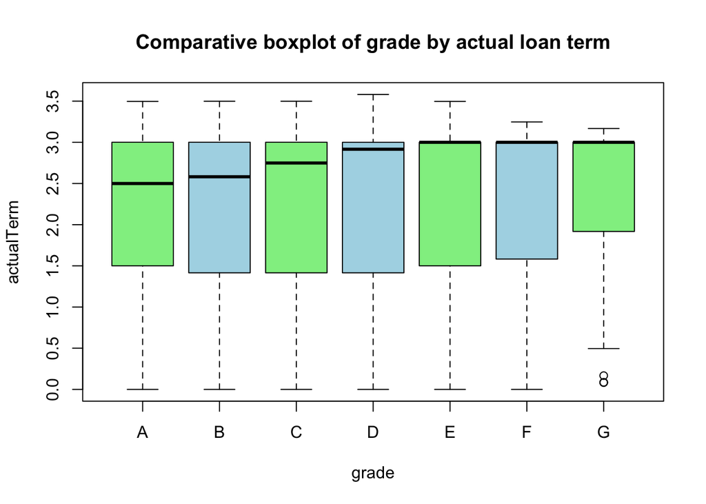

### **Question 2a - Part** (V)

**Calculate the annual return. Show how you calculate the percentage annual return. Is there any return from loans which are ‘charged off’? Explain. How does return from charged - off loans vary by loan grade? Compare the average return values with the average interest_rate on loans – do you notice any differences, and how do you explain this? How do returns vary by grade, and by sub-grade. If you wanted to invest in loans based on this data exploration, which loans would you invest in?**

The annual percentage return is calculated by: lcdf$actualReturn <- ifelse(lcdf$actualTerm>0, ((lcdf$total_pymnt -lcdf$funded_amnt)/lcdf$funded_amnt)*(1/lcdf$actualTerm)*100, 0)

Compared to the average interest rate on loans, average return and average interest rates generally increases as loan grade decreases. Although, in the lowest loan grade G, average return is lower than loan grade F.

The same pattern also follows within subgrades A through E; average return and average interest rates generally increase within subgrade as subgrade decreases. There is a variation in subgrades F and G: as interest rates increase, there is no pattern within the two subgrades. Subgrade G4 is the only subgrade with a negative return.

According to the data, the highest average return occurs in subgrade F4. This may be attractive for investing purposes, although F4 is a high-risk loan grade. To minimize risk, the best loans to invest in are the lowest risk loans (grade A) with the highest return (subgrade A5).

|  | loan_status | sum(actualReturn) |
| --- | --- | --- |
| 1 | Charged Off | -138346.2 |
| 2 | Fully Paid | 555728.1 |

| loan_status | grade | nLoans | totActRet | avgActRet |
| --- | --- | --- | --- | --- |
| Charged Off | A | 1108 | -12463.7102 | -11.248836 |
| Charged Off | B | 2682 | -29520.9363 | -11.007061 |
| Charged Off | C | 4116 | -47862.0413 | -11.628290 |
| Charged Off | D | 2647 | -32347.7334 | -12.220526 |
| Charged Off | E | 1045 | -13340.2999 | -12.765837 |
| Charged Off | F | 191 | -2394.7543 | -12.537981 |
| Charged Off | G | 38 | -416.7204 | -10.966326 |
| Fully Paid | A | 19294 | 92767.6660 | 4.808110 |
| Fully Paid | B | 20717 | 151607.2582 | 7.318012 |
| Fully Paid | C | 18461 | 177225.1800 | 9.599977 |

[output cut: 4 more lines]

|  | grade | avgActRet | avgInt |
| --- | --- | --- | --- |
| 1 | A | 3.936083 | 7.249607 |
| 2 | B | 5.217587 | 10.711802 |
| 3 | C | 5.729864 | 13.672434 |
| 4 | D | 5.887068 | 16.531698 |
| 5 | E | 5.446545 | 19.769035 |
| 6 | F | 7.286130 | 24.119196 |
| 7 | G | 6.332024 | 25.839890 |

```
## # A tibble: 35 x 3
##    sub_grade avgActRet avgInt
##  * <chr>         <dbl>  <dbl>
##  1 A1             3.55   6.03
##  2 A2             3.53   6.49
##  3 A3             3.92   7.05
##  4 A4             4.11   7.58
##  5 A5             4.28   8.27
##  6 B1             4.45   8.88
##  7 B2             4.77   9.77
##  8 B3             5.25  10.7
##  9 B4             5.72  11.5
## 10 B5             5.72  12.2
## 11 C1             5.70  12.7
## 12 C2             5.44  13.1
```

[output cut: 23 more lines]

### **Question 2a -** Part(VI) derived attributes

**Generate some (at least 3) new derived attributes which you think may be useful for predicting default, and explain what these are.** New attributes that could be helpful in predicting default include:

1. Loan status (fully paid vs. charged off) compared to num_bc_sats, the total number of the borrower’s satisfactory bankcard accounts. If the borrower has many satisfactory bankcard accounts, it may indicate lower risk of default.
2. Loan status (fully paid vs. charged off) compared to open_acc, the number of open credit lines in the borrower’s credit file. If the borrower has many open credit lines, it may indicate higher risk of default.
3. Loan status (fully paid vs. charged off) compared to acc_now_delinq, The number of accounts on which the borrower is now delinquent. If the borrower has many accounts with delinquencies, it may indicate higher risk of default.

```r
#Proportion of Satisfactory Bank Card
lcdf$propSatisBankcardAccts <- ifelse(lcdf$num_bc_tl>0, lcdf$num_bc_sats/lcdf$num_bc_tl, 0)

#Length of borrower history
lcdf$earliest_cr_line<-paste(lcdf$earliest_cr_line, "-01", sep = "")
lcdf$earliest_cr_line<-parse_date_time(lcdf$earliest_cr_line, "myd")
lcdf$borrHistory <- as.duration(lcdf$earliest_cr_line %--% lcdf$issue_d  ) / dyears(1)

#Ratio of open accounts
lcdf$ratio_openAccounts <- ifelse(lcdf$total_acc>0, lcdf$open_acc/lcdf$total_acc, 0)

#Proportion of delinquent accounts
lcdf$prop_delinquent <- ifelse(lcdf$open_acc>0, lcdf$acc_now_delinq/lcdf$open_acc,0)
```

### **Question 2**b - Missing values

**Are there missing values? What is the proportion of missing values in different variables? Explain how you will handle missing values for different variables. You should consider what the variable is about, and what missing values may arise from – for example, a variable monthsSinceLastDeliquency may have no value for someone who has not yet had a delinquency; what is a sensible value to replace the missing values in this case? Are there some variables you will exclude from your model due to missing values?**

Yes, there are missing values.

The variable mths_since_last_delinq has 48% missings values. We are going to replace those values with a value higher than the max (500) because the missing values pertain to non delinquency. We are going to use this same technique for the variables: mo_sin_old_il_acct=1000, mths_since_recent_bc=1000, and mths_since_recent_inq=50.

For the next variables we are going to handle missing values with the median: revol_util, bc_open_to_buy, percent_bc_gt_75, bc_util.

```r
#Drop vars with all empty values
dim(lcdf)
```

```
## [1] 81022   153
```

```r
lcdf <- lcdf %>% select_if(function(x){!all(is.na(x))})
dim(lcdf)
```

```
## [1] 81022   103
```

```r
#Of the columns remaining, names of columns with missing values
names(lcdf)[colSums(is.na(lcdf))>0]
```

```
##  [1] "emp_title"                      "mths_since_last_delinq"
##  [3] "mths_since_last_record"         "revol_util"
##  [5] "last_pymnt_d"                   "last_credit_pull_d"
##  [7] "mths_since_last_major_derog"    "bc_open_to_buy"
##  [9] "bc_util"                        "mo_sin_old_il_acct"
## [11] "mths_since_recent_bc"           "mths_since_recent_bc_dlq"
## [13] "mths_since_recent_inq"          "mths_since_recent_revol_delinq"
## [15] "num_tl_120dpd_2m"               "percent_bc_gt_75"
## [17] "hardship_dpd"                   "hardship_last_payment_amount"
## [19] "settlement_term"
```

```r
#missing value proportions in each column
colMeans(is.na(lcdf))
```

```
##                             X1                      loan_amnt
##                   0.0000000000                   0.0000000000
##                    funded_amnt                funded_amnt_inv
##                   0.0000000000                   0.0000000000
##                           term                       int_rate
##                   0.0000000000                   0.0000000000
##                    installment                          grade
##                   0.0000000000                   0.0000000000
##                      sub_grade                      emp_title
##                   0.0000000000                   0.0630939745
##                     emp_length                 home_ownership
##                   0.0000000000                   0.0000000000
##                     annual_inc            verification_status
##                   0.0000000000                   0.0000000000
##                        issue_d                    loan_status
##                   0.0000000000                   0.0000000000
##                     pymnt_plan                        purpose
##                   0.0000000000                   0.0000000000
##                          title                       zip_code
##                   0.0000000000                   0.0000000000
##                     addr_state                            dti
##                   0.0000000000                   0.0000000000
##                    delinq_2yrs               earliest_cr_line
##                   0.0000000000                   0.0000000000
##                 inq_last_6mths         mths_since_last_delinq
##                   0.0000000000                   0.4782898472
##         mths_since_last_record                       open_acc
##                   0.8178642838                   0.0000000000
##                        pub_rec                      revol_bal
##                   0.0000000000                   0.0000000000
##                     revol_util                      total_acc
##                   0.0004196391                   0.0000000000
##            initial_list_status                      out_prncp
##                   0.0000000000                   0.0000000000
##                  out_prncp_inv                    total_pymnt
##                   0.0000000000                   0.0000000000
##                total_pymnt_inv                total_rec_prncp
##                   0.0000000000                   0.0000000000
##                  total_rec_int             total_rec_late_fee
##                   0.0000000000                   0.0000000000
```

[output cut: 49 more lines]

```
##                   0.0000000000                   0.0000000000
##                  hardship_flag                   hardship_dpd
##                   0.0000000000                   0.9996790995
##   hardship_last_payment_amount            disbursement_method
##                   0.9999876577                   0.0000000000
##           debt_settlement_flag                settlement_term
##                   0.0000000000                   0.9950137000
##                         annRet                     actualTerm
##                   0.0000000000                   0.0000000000
##                   actualReturn         propSatisBankcardAccts
##                   0.0000000000                   0.0000000000
##                    borrHistory             ratio_openAccounts
##                   0.0000000000                   0.0000000000
##                prop_delinquent
##                   0.0000000000
```

```r
# or, get only those columns where there are missing values
colMeans(is.na(lcdf))[colMeans(is.na(lcdf))>0]
```

```
##                      emp_title         mths_since_last_delinq
##                   0.0630939745                   0.4782898472
##         mths_since_last_record                     revol_util
##                   0.8178642838                   0.0004196391
##                   last_pymnt_d             last_credit_pull_d
##                   0.0005554047                   0.0001481079
##    mths_since_last_major_derog                 bc_open_to_buy
##                   0.7033521760                   0.0120584533
##                        bc_util             mo_sin_old_il_acct
##                   0.0126879119                   0.0375330157
##           mths_since_recent_bc       mths_since_recent_bc_dlq
##                   0.0112068327                   0.7287526845
##          mths_since_recent_inq mths_since_recent_revol_delinq
##                   0.1014786107                   0.6293352423
##               num_tl_120dpd_2m               percent_bc_gt_75
##                   0.0257831206                   0.0124534077
##                   hardship_dpd   hardship_last_payment_amount
##                   0.9996790995                   0.9999876577
##                settlement_term
##                   0.9950137000
```

```r
#remove variables which have more than 60% missing values
nm<-names(lcdf)[colMeans(is.na(lcdf))>0.6]
lcdf <- lcdf %>% select(-nm)
```

```
## Note: Using an external vector in selections is ambiguous.
## ℹ Use `all_of(nm)` instead of `nm` to silence this message.
## ℹ See <https://tidyselect.r-lib.org/reference/faq-external-vector.html>.
```

```r
#Impute missing values - first get the columns with missing values
colMeans(is.na(lcdf))[colMeans(is.na(lcdf))>0]
```

```
##              emp_title mths_since_last_delinq             revol_util
##           0.0630939745           0.4782898472           0.0004196391
##           last_pymnt_d     last_credit_pull_d         bc_open_to_buy
##           0.0005554047           0.0001481079           0.0120584533
##                bc_util     mo_sin_old_il_acct   mths_since_recent_bc
##           0.0126879119           0.0375330157           0.0112068327
##  mths_since_recent_inq       num_tl_120dpd_2m       percent_bc_gt_75
##           0.1014786107           0.0257831206           0.0124534077
```

```r
#summary of data in these columns
nm<- names(lcdf)[colSums(is.na(lcdf))>0]
summary(lcdf[, nm])
```

```
##   emp_title         mths_since_last_delinq   revol_util
##  Length:81022       Min.   :  0.00         Min.   :  0.00
##  Class :character   1st Qu.: 15.00         1st Qu.: 36.50
##  Mode  :character   Median : 30.00         Median : 54.35
##                     Mean   : 33.63         Mean   : 54.22
##                     3rd Qu.: 49.00         3rd Qu.: 72.20
##                     Max.   :133.00         Max.   :184.60
##                     NA's   :38752          NA's   :34
##   last_pymnt_d                 last_credit_pull_d bc_open_to_buy
##  Min.   :2014-09-01 00:00:00   Length:81022       Min.   :     0
##  1st Qu.:2016-01-01 00:00:00   Class :character   1st Qu.:  1025
##  Median :2017-01-01 00:00:00   Mode  :character   Median :  3656
##  Mean   :2016-11-05 04:39:00                      Mean   :  8854
##  3rd Qu.:2017-10-01 00:00:00                      3rd Qu.: 10377
##  Max.   :2018-08-01 00:00:00                      Max.   :264424
##  NA's   :45                                       NA's   :977
##     bc_util       mo_sin_old_il_acct mths_since_recent_bc mths_since_recent_inq
##  Min.   :  0.00   Min.   :  1.0      Min.   :  0.00       Min.   : 0.000
##  1st Qu.: 43.30   1st Qu.: 96.0      1st Qu.:  6.00       1st Qu.: 2.000
##  Median : 67.30   Median :128.0      Median : 13.00       Median : 5.000
##  Mean   : 63.46   Mean   :124.8      Mean   : 23.92       Mean   : 6.731
##  3rd Qu.: 87.40   3rd Qu.:152.0      3rd Qu.: 29.00       3rd Qu.:10.000
##  Max.   :318.20   Max.   :545.0      Max.   :451.00       Max.   :25.000
##  NA's   :1028     NA's   :3041       NA's   :908          NA's   :8222
##  num_tl_120dpd_2m percent_bc_gt_75
##  Min.   :0.000    Min.   :  0.00
##  1st Qu.:0.000    1st Qu.: 20.00
##  Median :0.000    Median : 50.00
##  Mean   :0.001    Mean   : 49.43
##  3rd Qu.:0.000    3rd Qu.: 80.00
##  Max.   :3.000    Max.   :100.00
##  NA's   :2089     NA's   :1009
```

```r
#mths_since_last_delinq: has 48% missings, these pertain to no delinquincy,
#so replace by max value (176) or a value higher than the max (500) -- we will try this
#out and put results in a temporary dataset lcx,
#with the attributes that have missng values
lcx<-lcdf[, c(nm)]
colMeans(is.na(lcx))[colMeans(is.na(lcx))>0]
```

```
##              emp_title mths_since_last_delinq             revol_util
##           0.0630939745           0.4782898472           0.0004196391
##           last_pymnt_d     last_credit_pull_d         bc_open_to_buy
##           0.0005554047           0.0001481079           0.0120584533
##                bc_util     mo_sin_old_il_acct   mths_since_recent_bc
##           0.0126879119           0.0375330157           0.0112068327
##  mths_since_recent_inq       num_tl_120dpd_2m       percent_bc_gt_75
##           0.1014786107           0.0257831206           0.0124534077
```

```r
lcx<- lcx %>% replace_na(list(mths_since_last_delinq = 500))
#For revol_util, suppose we want to replace the misisng values by the median
lcx<- lcx %>% replace_na(list(revol_util=median(lcx$revol_util, na.rm=TRUE)))

#Similarly for the other variables
#After trying this out on the temporary dataframe lcx, if we are sure this is what we want, we can now  replace the missing values on the lcdf dataset
lcdf<- lcdf %>% replace_na(list(mths_since_last_delinq=500, revol_util=median(lcdf$revol_util, na.rm=TRUE), bc_open_to_buy=median(lcdf$bc_open_to_buy, na.rm=TRUE), mo_sin_old_il_acct=1000, mths_since_recent_bc=1000, mths_since_recent_inq=50, num_tl_120dpd_2m = median(lcdf$num_tl_120dpd_2m, na.rm=TRUE),percent_bc_gt_75 = median(lcdf$percent_bc_gt_75, na.rm=TRUE), bc_util=median(lcdf$bc_util, na.rm=TRUE) ))


#Have we addressed all missing values ?
colMeans(is.na(lcdf))[colMeans(is.na(lcdf))>0]
```

```
##          emp_title       last_pymnt_d last_credit_pull_d
##       0.0630939745       0.0005554047       0.0001481079
```

```r
  #You will see that last_pymnt_d still have a few missing values - do you understand what these missing values are for?
  # Are they probably for the charged-off loans ?  You can check:
  #lcdf %>% filter(is.na(lcdf$last_pymnt_d)) %>% group_by(loan_status) %>% tally()
```

### **Question 3**

Consider the potential for data leakage. You do not want to include variables in your model which may not be available when applying the model; that is, some data may not be available for new loans before they are funded. Leakage may also arise from variables in the data which may have been updated during the loan period (ie., after the loan is funded). Identify and explain which variables will you exclude from the model.

```r
lcdf <- lcdf %>% select(-c(funded_amnt_inv, term, emp_title, pymnt_plan, title, zip_code, addr_state, out_prncp, out_prncp_inv, total_pymnt_inv, total_rec_prncp, total_rec_int, last_credit_pull_d, policy_code, disbursement_method, debt_settlement_flag, hardship_flag, application_type, acc_now_delinq,acc_open_past_24mths, addr_state, annual_inc, application_type, avg_cur_bal, bc_open_to_buy, bc_util, chargeoff_within_12_mths, collection_recovery_fee, collections_12_mths_ex_med, delinq_2yrs, delinq_amnt, funded_amnt, funded_amnt_inv, initial_list_status, inq_last_6mths, installment, int_rate, issue_d, last_credit_pull_d, last_pymnt_amnt, last_pymnt_d, mo_sin_old_il_acct, mo_sin_old_rev_tl_op, mo_sin_rcnt_rev_tl_op, mo_sin_rcnt_tl, mort_acc, mths_since_last_delinq, mths_since_recent_bc, mths_since_recent_inq, num_accts_ever_120_pd, num_actv_bc_tl, num_actv_rev_tl, num_bc_sats, num_bc_tl, num_il_tl, num_op_rev_tl, num_rev_accts, num_rev_tl_bal_gt_0, num_sats, num_tl_120dpd_2m, num_tl_30dpd, num_tl_90g_dpd_24m, num_tl_op_past_12m, open_acc, out_prncp, out_prncp_inv, pct_tl_nvr_dlq, percent_bc_gt_75, policy_code, pub_rec, pub_rec_bankruptcies, pymnt_plan, recoveries, revol_bal, revol_util, tax_liens, term, title, tot_coll_amt, tot_cur_bal, tot_hi_cred_lim, total_acc, total_bal_ex_mort, total_bc_limit, total_il_high_credit_limit, total_pymnt, total_pymnt_inv, total_rec_int, total_rec_prncp, total_rev_hi_lim, hardship_flag, disbursement_method, X1))

#Drop some other variables
varsToRemove <- c("actualTerm","annRet")
lcdf <- lcdf %>% select(-varsToRemove)
```

```
## Note: Using an external vector in selections is ambiguous.
## ℹ Use `all_of(varsToRemove)` instead of `varsToRemove` to silence this message.
## ℹ See <https://tidyselect.r-lib.org/reference/faq-external-vector.html>.
```

### **Question 4**

Do a uni-variate analyses to determine which variables (from among those you decide to consider for the next stage prediction task) will be individually useful for predicting the dependent variable (loan_status). For this, you need a measure of relationship between the dependent variable and each of the potential predictor variables. Given loan-status as a binary dependent variable, which measure will you use? From your analyses using this measure, which variables do you think will be useful for predicting loan_status ?

(Note – if certain variables on their own are highly predictive of the outcome, it is good to ask if this variable has a leakage issue).

## Uni-variate analyses - which variables are individually predictive of the outcome ?

```r
#Can compute the AUC for each variable

lcdf <- lcdf %>% mutate_if(is.character, as.factor)
library(pROC) #this package has a function auc(..) which we can readily use

#We will use the function auc(response, prediction) which returns the AUC value for the specified predictor variable, and considering the response variable as the dependent.
auc(response=lcdfTrn$loan_status, lcdfTrn$loan_amnt)
```

```
## Area under the curve: 0.5104
```

```r
 # returns the value for loan_amt as predictor

#In the auc(..) function, the predictor variable has to be numeric  - otherwise, how would it calculate the AUC.  For a factor variable, we can consider the factors as numbers:
auc(response=lcdfTrn$loan_status, as.numeric(lcdfTrn$emp_length))
```

```
## Area under the curve: 0.5303
```

```r
# There are a few date type variables - we will ignore these here.

#How would you do this for all variables in the dataset?
# Rather than call the function individually for each variable, we can use the sapply(..) function

# For the numeric variables:
aucsNum<-sapply(lcdfTrn %>% select_if(is.numeric), auc, response=lcdfTrn$loan_status)

#Or considering both numeric and factor variables:
aucAll<- sapply(lcdfTrn %>% mutate_if(is.factor, as.numeric) %>% select_if(is.numeric), auc, response=lcdfTrn$loan_status)

#TO determine which variables have auc > 0.5
aucAll[aucAll>0.5]
```

```
##              loan_amnt             emp_length                    dti
##              0.5104229              0.5303488              0.5780818
##           actualReturn propSatisBankcardAccts            borrHistory
##              0.9857368              0.5241628              0.5454098
##     ratio_openAccounts
##              0.5392165
```

```r
#Or, we can use the tidy(..) function from the broom package - which converts the 'messy' output into a tidy form as a tibble
library(broom)

tidy(aucAll[aucAll > 0.5]) %>% view()

# or  in any range of values like, tidy(aucAll[aucAll >=0.5 & aucAll < 0.6])
# or in sorted order
tidy(aucAll) %>% arrange(desc(aucAll))
```

| names | x |
| --- | --- |
| actualReturn | 0.9857368 |
| dti | 0.5780818 |
| borrHistory | 0.5454098 |
| ratio_openAccounts | 0.5392165 |
| emp_length | 0.5303488 |
| propSatisBankcardAccts | 0.5241628 |
| loan_amnt | 0.5104229 |
| prop_delinquent | 0.4995962 |
| purpose | 0.4754586 |
| total_rec_late_fee | 0.4523300 |